# SpikeProject

Yaniela Fernandez M.

4/19/2021

## 1.Datos: Precipitaciones, Indicadores Económicos Banco Central

```r
library(stringr)
library(ggplot2)
library(lattice)
library(zoo)
library(xts)
library('Hmisc')
library(dygraphs)
library(tidyr)

# Cargando los datasets
precip <- read.csv("precipitaciones.csv", na.strings=c("NA","#DIV/0!", ""))
banc<-read.csv("banco_central.csv", na.strings=c("NA","#DIV/0!", ""))
```

## 2.Análisis de datos. Creación de variables

*2.1.Realiza un análisis exploratorio de la base de datos. ¿Qué puedes decir de los datos,sus distribuciones, valores faltantes,otros? ¿Hay algo que te llame la atención?*

El resumen estadístico más básico de una lista de objetos o números es su distribución. Una vez que un vector o variable de un datset se haya resumido como una distribución, existen varias técnicas de visualización de datos para transmitir esta información de manera efectiva.

En este caso vamos a realizar una exploración de cada una de las variables de los datsets *precipitaciones.csv* y *banco_central.csv*

### Análisis del dataset precipitaciones.csv

```r
summary(precip)
```

```
##      date              Coquimbo          Valparaiso
##  Length:496         Min.   :  0.0000   Min.   :  0.000
##  Class :character   1st Qu.:  0.8215   1st Qu.:  1.538
##  Mode  :character   Median :  4.0710   Median :  9.038
##                     Mean   : 16.1547   Mean   : 32.451
##                     3rd Qu.: 16.1376   3rd Qu.: 38.409
##                     Max.   :347.1339   Max.   :441.049
##  Metropolitana_de_Santiago Libertador_Gral__Bernardo_O_Higgins     Maule
##  Min.   :  0.000           Min.   :  0.000                     Min.   :  0.00
##  1st Qu.:  5.298           1st Qu.:  5.344                     1st Qu.: 11.90
##  Median : 19.088           Median : 25.996                     Median : 45.65
##  Mean   : 49.667           Mean   : 72.250                     Mean   : 98.66
##  3rd Qu.: 63.408           3rd Qu.:101.875                     3rd Qu.:142.23
##  Max.   :524.593           Max.   :645.516                     Max.   :759.18
##      Biobio          La_Araucania         Los_Rios
##  Min.   :  0.0012   Min.   :  0.0053   Min.   :  0.7481
##  1st Qu.: 29.3567   1st Qu.: 52.9303   1st Qu.: 89.8056
##  Median : 79.5586   Median :110.5710   Median :159.4679
##  Mean   :128.1134   Mean   :151.4865   Mean   :199.4518
##  3rd Qu.:184.7513   3rd Qu.:208.3162   3rd Qu.:274.5946
##  Max.   :702.4347   Max.   :661.2112   Max.   :717.7357
```

Se observan 9 variables con 496 filas. El dataset no presenta valores NA, tomanos como este tipo de valores las celdas con *"“*,* ”NA"* y *“#DIV/0!”*. Se observa los valores medios y la mediana de precipitaciones en cada region, siendo la región de los Rios donde cae la mayor cantidad de precipitaciones como promedio 199.4518. Observaremos mejor la distribucion de estas variables en la Fig 1.

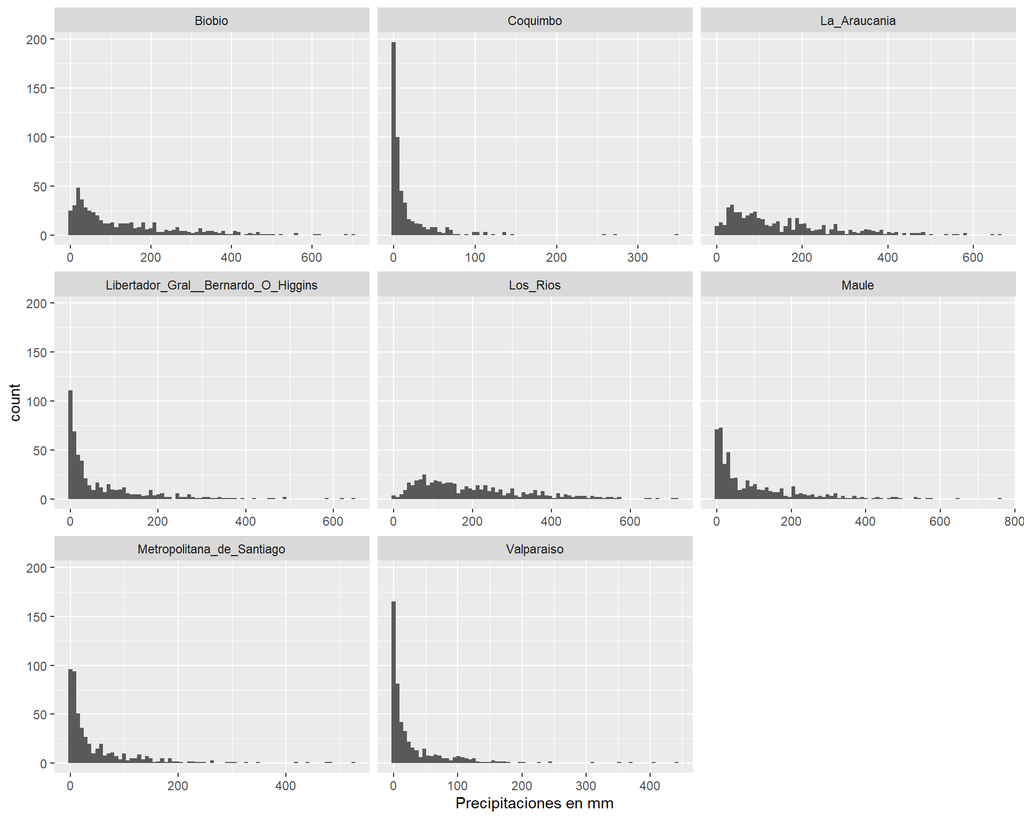

**Fig 1: Distribucion de las variables precipitaciones por regiones**

```r
df<-precip[,-1]

# la funcion gather convierte df en dos columnas key(con el nombre de las columnas) y value (los  valores de cada columna)

 # key       value
#1 Coquimbo 0.719032676
#2 Coquimbo 0.065215687
#3 Coquimbo 2.030026141
#4 Coquimbo 0.622784314
#5 Coquimbo 0.008065359
#6 Coquimbo 0.239366014

ggplot(gather(df), aes(value)) +
  geom_histogram(bins = 75)  +
  facet_wrap(~key, scales = 'free_x')+xlab("Precipitaciones en mm")
```

Se observa una distribución que no es simétrica, correspondiente a la ecuación de Gumbel, donde los valores mas frecuentes(pico de la campana) son más bajos que la media.Por tanto vamos a calcular las medianas de cada region y graficarlas en la Fig 2. para ver qué region(es) presenta(n) las mayores precipitaciones medias anuales.

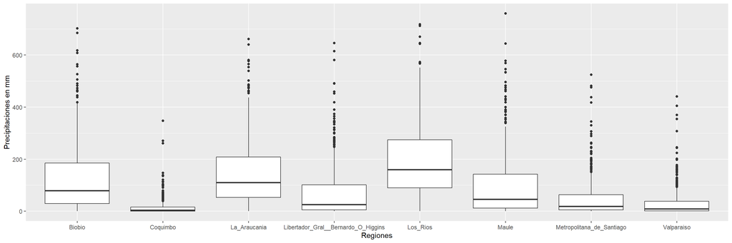

**Fig 2: Precipitaciones medias anuales por región**

```r
ggplot(gather(df), aes(y=value, x=key)) + xlab("Regiones") + ylab("Precipitaciones en mm")+
geom_boxplot()
```

Se observa que las regiones de mayores precitaciones anuales son Los Ríos y La Araucania. Aqui lo que tendría pensado es transformar el dataset para obtener el promedio general de las precipitaciones en todo chile y no trabajar por regiones.

```r
## No existen filas duplicadas en precip
sum(duplicated(precip)==TRUE)
```

```
## [1] 0
```

### Estructura del dataframe banc

En el dataset del banco central la mayoria de los valores son de tipo cadena, excepto la variable ventas, por lo que vamos a convertir a numeric los que tienen que ver con el precio, el PIB, la Ocupación, impuesto al valor agregado y derechos de importacion.

```r
summary(banc)
```

[output not shown]

Cambiar a numeric los valores correspondientes

```r
#Cambiar a numerico el PIB que esta en millones

indexPib<-grep("PIB",colnames(banc), fixed = TRUE)
indexPrecio<-grep("Precio",colnames(banc), fixed = TRUE)
indexImacec<-grep("Imacec",colnames(banc), fixed = TRUE)

 for(i in 1:length(indexPib)){
   banc[,indexPib[i]]<-gsub("[:alpha:]","",banc[,indexPib[i]],fixed=TRUE)
   banc[,indexPib[i]]<-as.numeric(gsub(".","",banc[,indexPib[i]],fixed=TRUE))
   banc[,indexPib[i]]<-banc[,indexPib[i]]/1e6

 }

for(i in 1:length(indexPrecio)){
  banc[,indexPrecio[i]]<-gsub("[:alpha:]","",banc[,indexPrecio[i]],fixed=TRUE)
  banc[,indexPrecio[i]]<-as.numeric(banc[,indexPrecio[i]])
}

for(i in 1:length(indexImacec)){
  banc[,indexImacec[i]]<-gsub("[:alpha:]","",banc[,indexImacec[i]],fixed=TRUE)
  banc[,indexImacec[i]]<-as.numeric(gsub(".","",banc[,indexImacec[i]],fixed=TRUE))
  banc[,indexImacec[i]]<-banc[,indexImacec[i]]/1e6
}

#falta cambiar el impuesto, los indices y la ocupacion

for(i in 38:39){
  banc[,i]<-gsub("[:alpha:]","",banc[,i],fixed=TRUE)
  banc[,i]<-as.numeric(gsub(".","",banc[,i],fixed=TRUE))
  banc[,i]<-banc[,i]/1e6
}

for(i in 52:74){
  banc[,i]<-gsub("[:alpha:]","",banc[,i],fixed=TRUE)
  banc[,i]<-as.numeric(gsub(".","",banc[,i],fixed=TRUE))
  banc[,i]<-banc[,i]/1e6
}

for(i in 75:84){
  banc[,i]<-gsub("[:alpha:]","",banc[,i],fixed=TRUE)
  banc[,i]<-as.numeric(gsub(".","",banc[,i],fixed=TRUE))
  banc[,i]<-banc[,i]/1e6
}
```

La Fig 3 muestra las columnas con valores NA. Varias sobrepasan el 50% de celdas con estos valores.

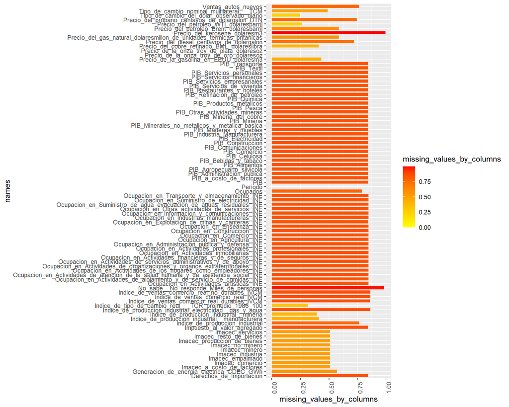

**Fig 3: Comportamiento de los Valores NA por columnas**

```r
missing_values_by_columns<-apply(is.na(banc), 2, mean)
df<-as.data.frame(missing_values_by_columns)
df$names<-row.names(df)
plot1 <-ggplot(data = df, aes(x = missing_values_by_columns, y =names , fill = missing_values_by_columns)) + geom_bar(width =0.7, stat = "identity") + scale_fill_gradient(low = "yellow", high = "red") +theme(axis.text.x = element_text(angle = 90, hjust = 1))

print(plot1)
```

La cantidad de filas duplicadas en banc es solo 2.

```r
sum(duplicated(banc)==TRUE)
```

```
## [1] 2
```

```r
sum(duplicated(precip)==TRUE)
```

```
## [1] 0
```

```r
summary(banc)
```

```
##    Periodo          Imacec_empalmado  Imacec_produccion_de_bienes
##  Length:614         Min.   :  5.297   Min.   :  1.015
##  Class :character   1st Qu.:109.688   1st Qu.:109.938
##  Mode  :character   Median :564.857   Median :752.522
##                     Mean   :504.625   Mean   :612.678
##                     3rd Qu.:776.917   3rd Qu.:885.670
##                     Max.   :999.875   Max.   :999.273
##                     NA's   :314       NA's   :314
##  Imacec_minero   Imacec_industria  Imacec_resto_de_bienes Imacec_comercio
##  Min.   : 10.1   Min.   :  1.032   Min.   :  1.027        Min.   :  4.237
##  1st Qu.:106.6   1st Qu.:106.705   1st Qu.:129.528        1st Qu.:121.312
##  Median :862.0   Median :737.349   Median :634.644        Median :444.829
##  Mean   :642.7   Mean   :611.868   Mean   :558.623        Mean   :460.744
##  3rd Qu.:942.8   3rd Qu.:888.272   3rd Qu.:812.302        3rd Qu.:666.994
##  Max.   :997.6   Max.   :999.212   Max.   :999.585        Max.   :997.181
##  NA's   :314     NA's   :314       NA's   :314            NA's   :313
##  Imacec_servicios   Imacec_a_costo_de_factores Imacec_no_minero
##  Min.   :  0.7564   Min.   :  9.371            Min.   :  0.9043
##  1st Qu.:109.4721   1st Qu.:108.560            1st Qu.:110.2778
##  Median :479.2928   Median :571.612            Median :522.3304
##  Mean   :441.5409   Mean   :494.621            Mean   :480.3953
##  3rd Qu.:686.2097   3rd Qu.:759.634            3rd Qu.:749.8437
##  Max.   :996.4286   Max.   :998.154            Max.   :997.2512
##  NA's   :314        NA's   :314                NA's   :314
##  PIB_Agropecuario_silvicola   PIB_Pesca      PIB_Mineria
##  Min.   : 15.87             Min.   : 10.4   Min.   :  1.271
##  1st Qu.:177.78             1st Qu.:435.5   1st Qu.:120.638
##  Median :267.63             Median :558.9   Median :126.942
##  Mean   :311.81             Mean   :521.4   Mean   :116.140
##  3rd Qu.:397.62             3rd Qu.:670.9   3rd Qu.:132.233
##  Max.   :704.61             Max.   :989.5   Max.   :143.403
##  NA's   :519                NA's   :519     NA's   :519
##  PIB_Mineria_del_cobre PIB_Otras_actividades_mineras
##  Min.   : 10.36        Min.   :  1.293
##  1st Qu.:109.58        1st Qu.:120.989
##  Median :115.24        Median :131.320
##  Mean   :132.72        Mean   :135.056
##  3rd Qu.:119.49        3rd Qu.:139.686
##  Max.   :956.01        Max.   :973.297
##  NA's   :519           NA's   :518
```

[output cut: 353 more lines]

```
##  Min.   :  0.1009
##  1st Qu.:102.4565
##  Median :106.1352
##  Mean   :335.4685
##  3rd Qu.:827.6680
##  Max.   :998.6254
##  NA's   :530
##  Indice_de_ventas_comercio_real_durables_IVCM Ventas_autos_nuevos
##  Min.   : 10.07                               Min.   : 4658
##  1st Qu.:108.68                               1st Qu.:23701
##  Median :133.04                               Median :27912
##  Mean   :329.25                               Mean   :26694
##  3rd Qu.:796.43                               3rd Qu.:31800
##  Max.   :998.89                               Max.   :39263
##  NA's   :529                                  NA's   :469
```

*2.2.Realiza una limpieza de datos para que las series de tiempo no tengan duplicados ni valores incorrectos.*

```r
banc<-banc[!duplicated(banc),] ##Eliminando filas duplicadas

precip$date<-as.Date(precip$date) ## Transformando las fechas a Date
banc$Periodo<-as.Date(banc$Periodo)

#Revisando si existe alguna fila con fecha incorrecta en banc para eliminarla
sum(is.na(banc$Periodo)==TRUE)
```

```
## [1] 1
```

```r
# Como existe una fecha incorrecta elimino esa fila del dataset
banc<-banc[!is.na(banc$Periodo),]

#Revisando si existe alguna fila con fecha incorrecta en precip para eliminarla
sum(is.na(precip$date)==TRUE)
```

```
## [1] 0
```

# 3. Visualizacion

*3.1. Crea una función que permita graficar series históricas de precipitaciones para un rango de fechas determinado. Para esto la función debe recibir como argumentos el nombre de una región, fecha de inicio y fecha de término (asegúrate de verificar en tu función que tanto el nombre de la región como las fechas ingresadas existan en el dataset.*

*Usa esta función para graficar las precipitaciones para la Región Libertador General Bernardo O’Higgins y para la Región Metropolitana entre las fechas 2000-01-01 y 2020-01-01.¿ Qué observas con respecto a estacionalidades y tendencias?*

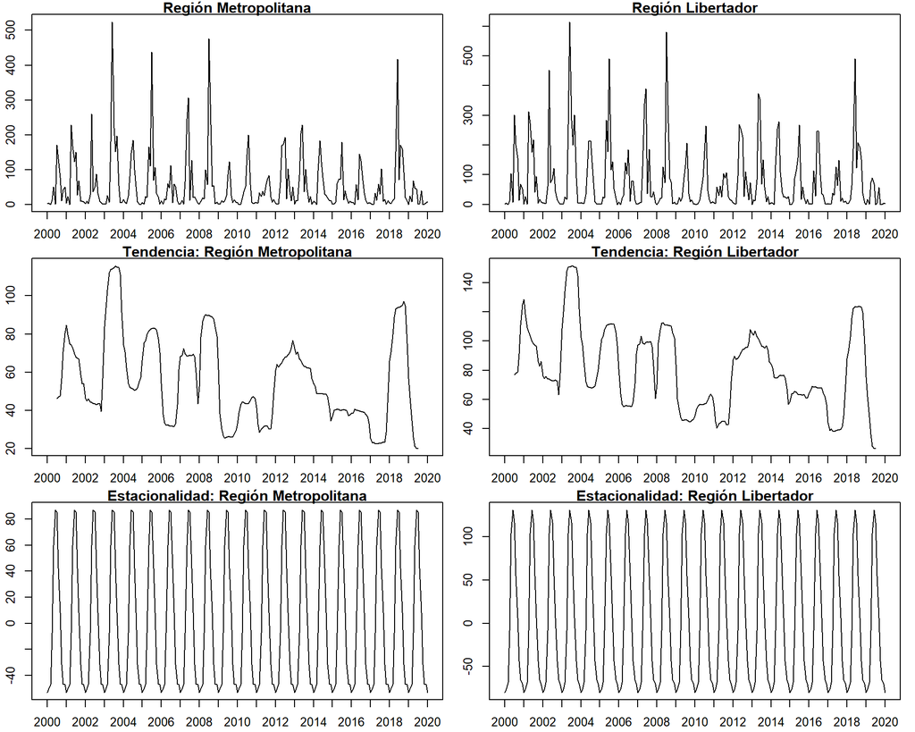

**Fig 4: Estacionalidades y tendencias de las precipitaciones en dos regiones**

```r
plotSerieByRegion <- function(region, inicDate, endDate) {

  inicDate<-as.Date(inicDate)
  endDate<-as.Date(endDate)

  if(is.null(inicDate)||is.null(endDate)){
    return( cat("Una de las fechas es invalida"))
  }

  region<- iconv(region,to="ASCII//TRANSLIT")# eliminar tilde
  region<-str_replace_all(region, "[^[:alnum:]]", "_")

  if(grepl("Libertador",region, fixed = TRUE))  region="Libertador_Gral__Bernardo_O_Higgins"
  if(grepl("Metropolitana",region, fixed = TRUE)) region="Metropolitana_de_Santiago"

  if(length(grep(region, colnames(precip), fixed = TRUE)))
      index=grep(region,colnames(precip), fixed = TRUE)

   else{ return( cat("La region: " , region , " no es válida"))

    }

  #Falta revisar que las fechas existan en el dataset

  precip_Sort<-precip[order(precip$date),]
  precipRegions<-precip_Sort[,index]

  preciptimeseries <- ts(precipRegions, frequency=12, start=c(format(inicDate, "%Y") ,format(inicDate, "%m")), end=c(format(endDate, "%Y") ,format(endDate, "%m")))

}

par(mfrow = c(3, 2),  mar = c(2.2, 2.2, 1, 1), cex = 0.8)
serieTemp1<-plotSerieByRegion(c("Metropolitana"), "2000-01-01", "2020-01-01")
serieTemp2<-plotSerieByRegion(c("Libertador"), "2000-01-01", "2020-01-01")

plot.ts(serieTemp1, axes=F, main="Región Metropolitana")
axis(2) # plot the y axis
axis(1, at=seq(from=2000,to=2020, by=1.0) )
box() # and the box around the plot

plot.ts(serieTemp2, axes=F,main="Región Libertador")
axis(2) # plot the y axis
axis(1, at=seq(from=2000,to=2020, by=1.0) )
box() # and the box around the plot

trendSerie1 <- decompose(serieTemp1)
trendSerie2 <- decompose(serieTemp2)

plot.ts(trendSerie1$trend, axes=F,main="Tendencia: Región Metropolitana")
axis(2) # plot the y axis
axis(1, at=seq(from=2000,to=2020, by=1.0) )
box() # and the box around the plot
plot.ts(trendSerie2$trend, axes=F,main="Tendencia: Región Libertador")
axis(2) # plot the y axis
axis(1, at=seq(from=2000,to=2020, by=1.0) )
box() # and the box around the plot


plot.ts(trendSerie1$seasonal, axes=F,main="Estacionalidad: Región Metropolitana")
axis(2) # plot the y axis
axis(1, at=seq(from=2000,to=2020, by=1.0) )
box() # and the box around the plot
plot.ts(trendSerie2$seasonal, axes=F,main="Estacionalidad: Región Libertador")
axis(2) # plot the y axis
axis(1, at=seq(from=2000,to=2020, by=1.0) )
box() # and the box around the plot
```

Las gráficas muestran las series originales en las regiones Metropolitana y Libertador (1ra desde el tope), la tendencia estimada de cada serie (2da), y el comportamiento estacional(3ra). Podemos observar que la tendencia de las precipitaciones es la misma en ambas regiones, con periodos de sequia en los años 2006, 2009, 2011 y 2017. El componente estacional, se mantiene constante en ambas gráficas a lo laro de los años, y los picos de precipitaciones ocurren a mitad de año entre los meses de Mayo y Agosto.

*3.2. Crea una función que, para una región,grafique múltiples series de tiempo mensuales de precipitaciones, donde cada serie de tiempo corresponda a un año. La función debe recibir como argumento una lista con los años que queremos graficar (2000, 2005,..) y el nombre de la región.El eje X debe indicar los meses (enero, febrero, etc…).*

*Usa esta función para graficar las precipitaciones para la Región del Maule durante los años 1982, 1992, 2002, 2012 y 2019.o¿Qué puedes concluir de estos gráficos?*

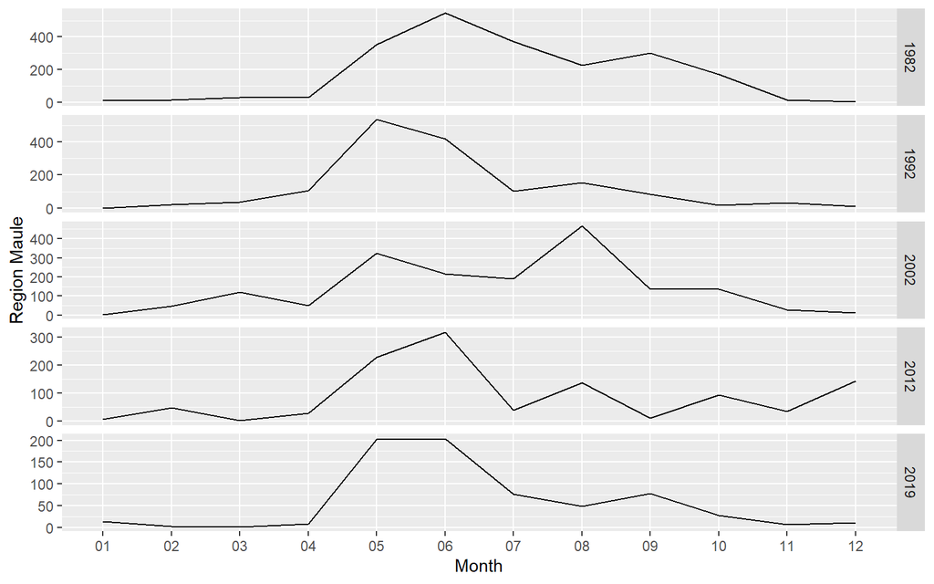

**Fig 5: Precipitaciones region del Maule**

```r
plotSerieByYear<-function(region, years){

  precip_Sort<-precip[order(precip$date),]
  if(length(grep(region, colnames(precip), fixed = TRUE))){
    index=grep(region,colnames(precip), fixed = TRUE)
  } else cat("La region: " , region , " no es válida")

  df<-precip_Sort[format(as.Date(precip_Sort$date), "%Y")  %in% years,c(1,index)]
  df$Year<-as.numeric(format(df$date, "%Y"))
  df$Month<-format(df$date, "%m")

  qplot(Month, df[,2], data = df, geom = "line", group = Year, ylab = str_c("Region ", region)) +
    facet_grid(df$Year ~ ., scale = "free_y")

}

plotSerieByYear("Maule",c("1982", "1992", "2002", "2012", "2019") )
```

*Crea una función que permita visualizar dos series históricas de PIB para un rango de fechas determinado. Para esto la función debe recibir como input el nombre de cada #serie,fecha de inicio y fecha de término.*

*Grafica las series de tiempo del PIB agropecuario y silvícola y la del PIB de Servicios financieros desde el 2013-01-01 hasta la fecha más reciente en que haya datos.¿Qué puedes decir de cada serie en particular?, ¿Hay alguna relación entre estas dos series?*

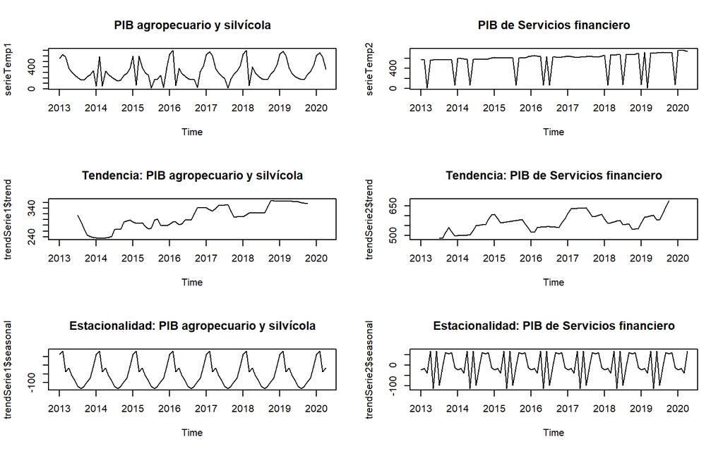

**Fig 6: Comportamiento del PIB agropecuario y silvícola, y de Servicios financieros**

```r
plotSeriesPIB<-function(name1="silvicola",name2="financieros", inicDate="2013-01-01", endDate="2020-04-01"){

  # validando los argumentos

  banc_Sort<-banc[order(banc$Periodo),]
  if(length(grep(name1, colnames(banc_Sort), fixed = TRUE))){
    index1=grep(name1, colnames(banc_Sort), fixed = TRUE)
  } else cat("El pib: " ,name1 , " no es válido")

  if(length(grep(name2, colnames(banc_Sort), fixed = TRUE))){
    index2=grep(name2, colnames(banc_Sort), fixed = TRUE)
  }

  inicDate<-as.Date(inicDate)
  endDate<-as.Date(endDate)

  # seleccionando las columnas del dataframe

  df<-banc_Sort[banc_Sort$Periodo>=inicDate & banc_Sort$Periodo<=endDate,c(1,index1, index2)]
  df[,2]<-as.numeric(df[,2])
  df[,3]<-as.numeric(df[,3])
  df %>% replace(is.na(.), 0)

  serieTemp1 <- ts(df[,2], frequency=12, start=c(format(inicDate, "%Y") ,format(inicDate, "%m")), end=c(format(endDate, "%Y") ,format(endDate, "%m")))
  serieTemp2 <- ts(df[,3], frequency=12, start=c(format(inicDate, "%Y") ,format(inicDate, "%m")), end=c(format(endDate, "%Y") ,format(endDate, "%m")))

  par(mfrow = c(3, 2))
  plot.ts(serieTemp1, axes=F, main="PIB agropecuario y silvícola")
  axis(2) # plot the y axis
  axis(1, at=seq(from=2013,to=2020, by=1.0) )
  box() # and the box around the plot

  plot.ts(serieTemp2, axes=F,main="PIB de Servicios financiero")
  axis(2) # plot the y axis
  axis(1, at=seq(from=2013,to=2020, by=1.0) )
  box() # and the box around the plot

  trendSerie1 <- decompose(serieTemp1)
  trendSerie2 <- decompose(serieTemp2)

  plot.ts(trendSerie1$trend, axes=F,main="Tendencia: PIB agropecuario y silvícola")
  axis(2) # plot the y axis
  axis(1, at=seq(from=2013,to=2020, by=1.0) )
  box() # and the box around the plot
  plot.ts(trendSerie2$trend, axes=F,main="Tendencia: PIB de Servicios financiero")
  axis(2) # plot the y axis
  axis(1, at=seq(from=2013,to=2020, by=1.0) )
  box() # and the box around the plot

  plot.ts(trendSerie1$seasonal, axes=F,main="Estacionalidad: PIB agropecuario y silvícola")
  axis(2) # plot the y axis
  axis(1, at=seq(from=2013,to=2020, by=1.0) )
  box() # and the box around the plot
  plot.ts(trendSerie2$seasonal, axes=F,main="Estacionalidad: PIB de Servicios financiero")
  axis(2) # plot the y axis
  axis(1, at=seq(from=2013,to=2020, by=1.0) )
  box() # and the box around the plot
}
plotSeriesPIB("silvicola", "financieros", "2013-01-01", "2020-04-01")
```

La serie de PIB agropecuario y silvícola presenta reducciones (a mitad de año) y aumentos (a inicios de año) por lo que tiene un componente estacional. El caso de la serie PIB de Servicios financiero presenta caidas variables(0, 1 o 2 veces en el mismo año). En ambas series la tendencia es a incrementar el valor, sin embargo de acuerdo a la estacionalidad los valores cambian, cuando una va en aumento la otra disminuye.

## 4. Tratamiento y creación de variables

*¿Cómo podríamos evaluar la correlación entre las distintas series de tiempo y cómo se tienen que correlacionar para entrenar un modelo? ¿Mucha correlación, no correlacionadas, da igual?*

La correlación depende del tipo de técnica o algoritm de predicción a utilizar. Si se escoge una regresión es importante que las variables tengan una fuerte correlación.